# Assignment 7

Luis Sanchez Mercedes

10/13/2021

### I. Questions on Your Selected Data

Use the data of your own. Produce the following types of plots and comment on each plot. Plots should be meaningful. If you use the data we used in class, make sure the plots are not the same as the ones in the slides. All plots should have title, caption, appropriate labels on x and y-axis.

```r
library(tidyverse)
library(lubridate)
# Link: https://www.kaggle.com/umutalpaydn/nba-20202021-season-player-stats
setwd("C:/Users/student/Downloads")
df_basketball <- read_csv('nba2021_advanced.csv', show_col_types = FALSE)
df_basketball
```

```
## # A tibble: 497 x 26
##    Player   Pos     Age Tm        G    MP   PER `TS%` `3PAr`   FTr `ORB%` `DRB%`
##    <chr>    <chr> <dbl> <chr> <dbl> <dbl> <dbl> <dbl>  <dbl> <dbl>  <dbl>  <dbl>
##  1 Preciou~ PF       21 MIA      28   408  15.1 0.599  0     0.541   10.5   19.8
##  2 Jaylen ~ PG       24 MIL       6    17  -6.9 0.125  0.25  0        0     18.2
##  3 Steven ~ C        27 NOP      27   760  15.9 0.592  0.006 0.397   16.9   18
##  4 Bam Ade~ C        23 MIA      26   873  22.7 0.641  0.015 0.469    6.8   23.2
##  5 LaMarcu~ C        35 SAS      18   480  15.2 0.542  0.298 0.093    3.2   14
##  6 Ty-Shon~ SG       22 PHO       3     8 -11.9 0      0.333 0        0     13.6
##  7 Nickeil~ SG       22 NOP      23   441  12   0.502  0.463 0.17     1.3   14.1
##  8 Grayson~ SG       25 MEM      19   454  14   0.63   0.721 0.264    1.7   12
##  9 Jarrett~ C        22 TOT      28   734  22.5 0.695  0.021 0.695   12.6   25.5
## 10 Jarrett~ C        22 BRK      12   320  21.3 0.73   0     0.938   14.2   28.8
## # ... with 487 more rows, and 14 more variables: TRB% <dbl>, AST% <dbl>,
## #   STL% <dbl>, BLK% <dbl>, TOV% <dbl>, USG% <dbl>, OWS <dbl>, DWS <dbl>,
## #   WS <dbl>, WS/48 <dbl>, OBPM <dbl>, DBPM <dbl>, BPM <dbl>, VORP <dbl>
```

1. Make a plot using `face_wrap` by one categorical variable (`face_wrap(~variable1)`)

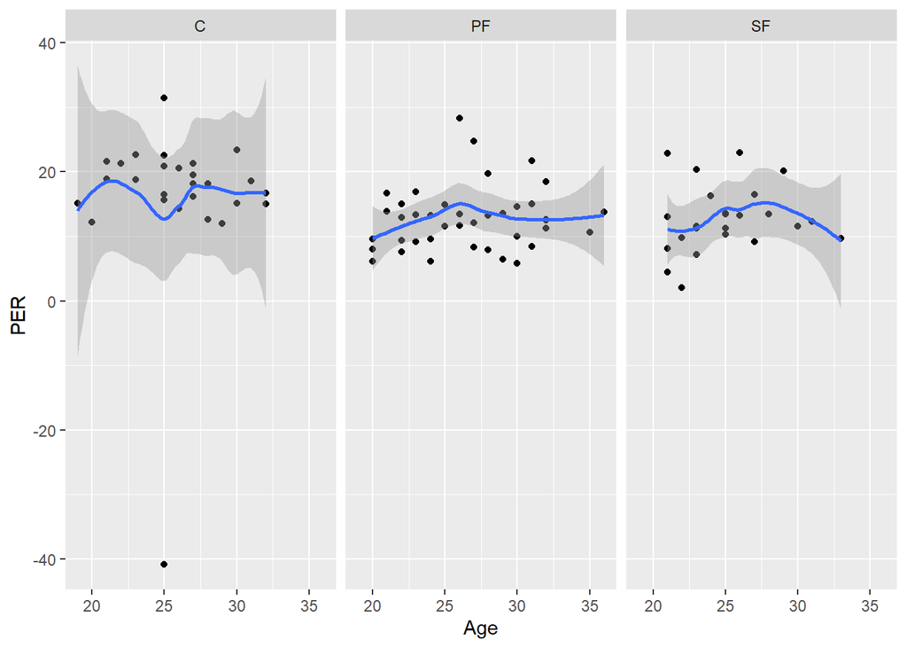

```r
df_basketball %>%
  filter(Pos==c('C','PF', 'SF')) %>%
   ggplot(mapping = aes(x=Age, y=PER)) +
    geom_point() +
    geom_smooth() +
    facet_wrap(~Pos)
```

2. Make a plot using `face_wrap` by two categorical variables (`face_wrap(variable1~variable2)`)

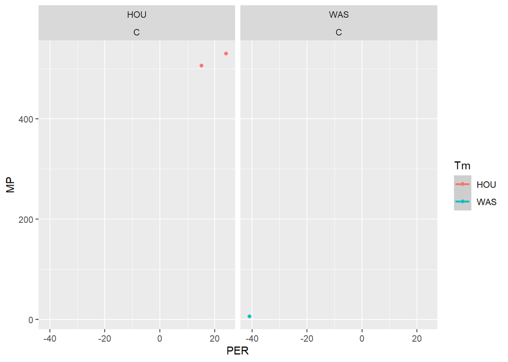

```r
df_basketball %>%
  filter(Tm==c('HOU', 'WAS')) %>%
  filter(Pos==c('C','PF', 'SF')) %>%
   ggplot(mapping = aes(x=PER, y=MP, color=Tm)) +
    geom_point() +
    geom_smooth() +
    facet_wrap(Tm~Pos)
```

3. Make a plot using `position ='jitter'`.

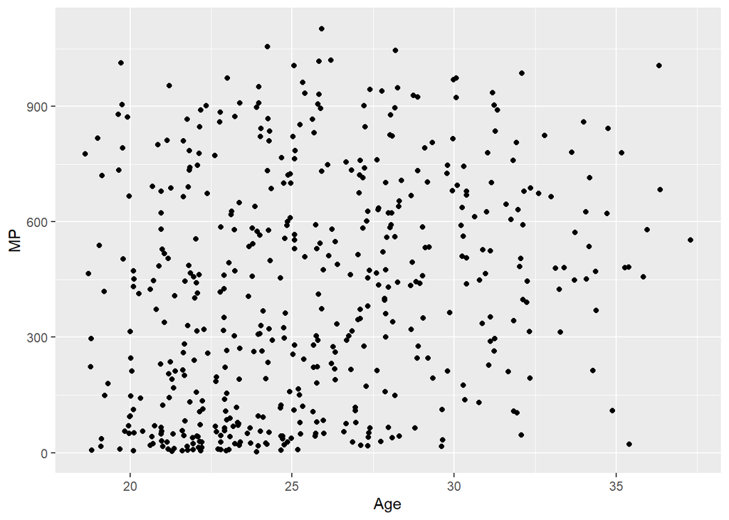

```r
df_basketball %>%
  ggplot() + geom_point(mapping=aes(x=Age, y=MP), position='jitter')
```

4. Make a plot using `position ='dodge'`.

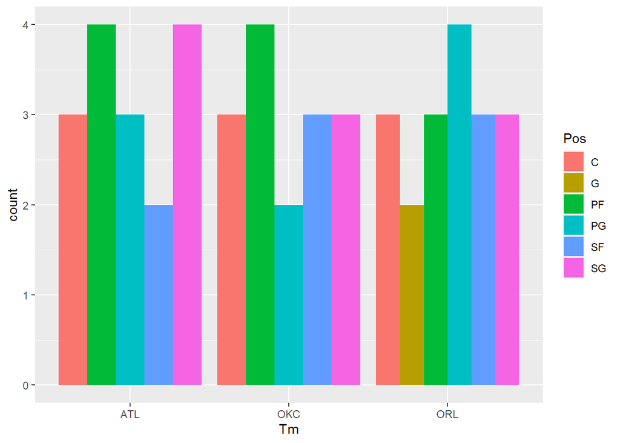

```r
df_basketball %>%
  filter(Tm=='ATL'|Tm=='OKC'|Tm=='ORL') %>%
  ggplot() + geom_bar(mapping=aes(x=Tm, fill=Pos), position='dodge')
```

5. Make a plot using `position ='fill'`.

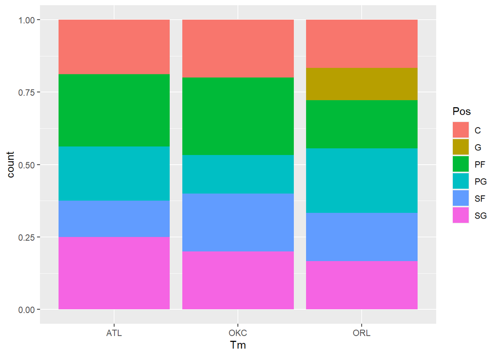

```r
df_basketball %>%
  filter(Tm=='ATL'|Tm=='OKC'|Tm=='ORL') %>%
  ggplot() + geom_bar(mapping=aes(x=Tm, fill=Pos), position='fill')
```

6. Make a plot using `geom_col`.

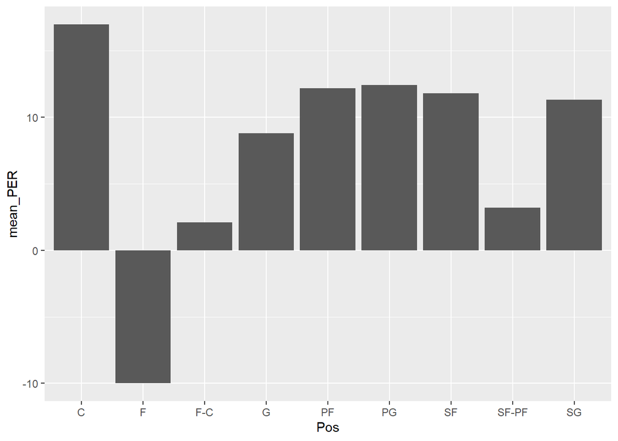

```r
df_basketball %>%
  group_by(Pos) %>%
  summarise(mean_PER=mean(PER), na.rm=TRUE) %>%
  ggplot() + geom_col(mapping=aes(x=Pos, y=mean_PER))
```

7. Change the theme of one of your plots.

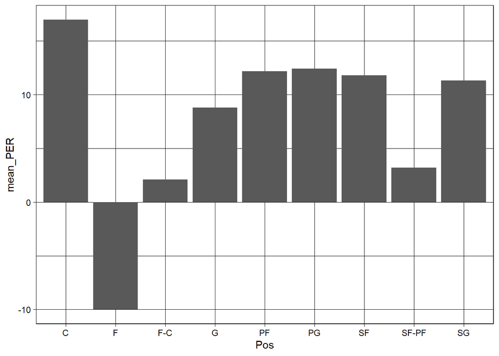

```r
df_basketball %>%
  group_by(Pos) %>%
  summarise(mean_PER=mean(PER), na.rm=TRUE) %>%
  ggplot() + geom_col(mapping=aes(x=Pos, y=mean_PER))+
  theme_linedraw()
```

8. Save a plot and put a link of the plot to your Github Webpage. To link a plot `abc.png` you just need to insert the following on the README.md

```r
image <- df_basketball %>%
  group_by(Pos) %>%
  summarise(mean_PER=mean(PER), na.rm=TRUE) %>%
  ggplot() + geom_col(mapping=aes(x=Pos, y=mean_PER))+
  theme_linedraw()

ggsave(filename = 'abc.png', plot=image)
[Link to the plot](abc.png)
```

### II. Questions on Covid Vaccination Data

In this section of questions, we will use the covid vaccination data for the US. The data and data dictionary can be found at the below link:

- [Data](https://raw.githubusercontent.com/govex/COVID-19/master/data_tables/vaccine_data/us_data/time_series/vaccine_data_us_timeline.csv)
- [Data Dictionary](https://github.com/govex/COVID-19/blob/master/data_tables/vaccine_data/us_data/data_dictionary.csv)

```r
df_vaccine <- read_csv('https://raw.githubusercontent.com/govex/COVID-19/master/data_tables/vaccine_data/us_data/time_series/vaccine_data_us_timeline.csv')
df_vaccine
```

```
## # A tibble: 101,608 x 13
##    Province_State Date       Vaccine_Type  FIPS Country_Region   Lat Long_
##    <chr>          <date>     <chr>        <dbl> <chr>          <dbl> <dbl>
##  1 Alabama        2020-12-10 All              1 US              32.3 -86.9
##  2 Alabama        2020-12-10 Moderna          1 US              32.3 -86.9
##  3 Alabama        2020-12-10 Pfizer           1 US              32.3 -86.9
##  4 Alabama        2020-12-11 All              1 US              32.3 -86.9
##  5 Alabama        2020-12-11 Moderna          1 US              32.3 -86.9
##  6 Alabama        2020-12-11 Pfizer           1 US              32.3 -86.9
##  7 Alabama        2020-12-12 All              1 US              32.3 -86.9
##  8 Alabama        2020-12-12 Moderna          1 US              32.3 -86.9
##  9 Alabama        2020-12-12 Pfizer           1 US              32.3 -86.9
## 10 Alabama        2020-12-13 All              1 US              32.3 -86.9
## # ... with 101,598 more rows, and 6 more variables: Doses_alloc <dbl>,
## #   Doses_shipped <dbl>, Doses_admin <dbl>, Stage_One_Doses <dbl>,
## #   Stage_Two_Doses <dbl>, Combined_Key <chr>
```

1. Put titles, captions, appropriate labels on x and y-axis for the last two questions in Assignments 6.

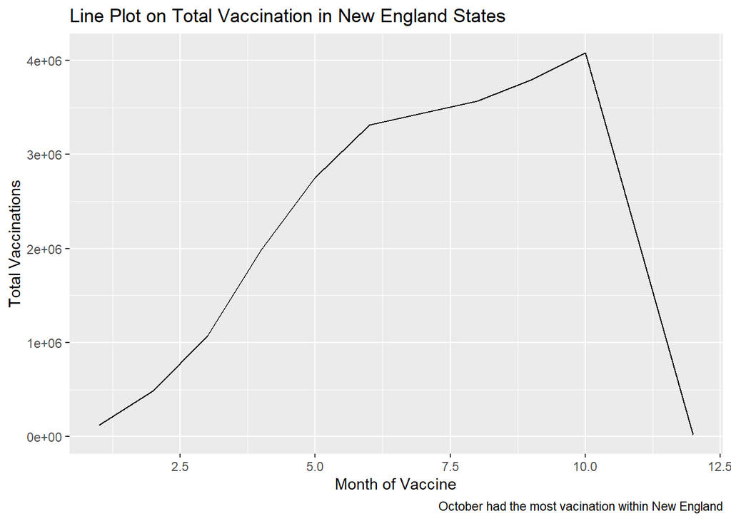

```r
new_england <- c('Maine', 'Vermont', 'New Hampshire', 'Massachusetts', 'Connecticut', ' Rhode Island')

df_vaccine$Month <- month(df_vaccine$Date)

df_vaccine %>%
  filter(Vaccine_Type=='All') %>%
  filter(Province_State==new_england) %>%
  group_by(Month) %>%
  summarise(vac_admin=mean(Doses_admin, na.rm=TRUE)) %>%
  ggplot()+geom_line(mapping=aes(x=Month, y=vac_admin))+
  labs(x='Month of Vaccine',
         y='Total Vaccinations',
         title='Line Plot on Total Vaccination in New England States',
         caption='October had the most vacination within New England')
```